# Marketing Resource Allocation

Companies spend a staggering amount of their money on marketing these days. Advertising (TV spots, Radio, print, online display, etc), distribution channel, packaging design–marketing managers have more options at their disposal than ever before. But how should they decide how much money to spend on each of these aspects?The good news is that an increasing availability of data, combined with more sophisticated methods of analyzing it, provide managers with powerful tools to help them isolate the effects of various marketing instruments.

Imagine the following scenario:

The marketing department of the ABC company operating in kitchne applicance industry in an emerging market provided you with a dataset that covers sales, spending on offline flyer advertising, and spending on Google Adwords. Since ABC is spending a lot of money on these two activities, the CMO, in preparation for a meeting with the CEO, is interested to know if the expenditures are effective enough to drive up the sales. Meanwhile, the CFO is also interested in possible optimization on the current budget allocation, since the profitability of the brand is not increasing as much as expected.  
Now as the marketing analytics department you are given the firm’s historical revenues and marketing expenditure on flyer advertising and Adwords advertising over a time span of 122 weeks.

Here is a brief pre-view of the data:

| Week | Revenues | Flyer | Adwords |
| --- | --- | --- | --- |
| 1 | 115792.4 | 0.00 | 999.860 |
| 2 | 183189.5 | 17134.21 | 1011.395 |
| 3 | 210107.5 | 0.00 | 1049.560 |
| 4 | 227392.5 | 0.00 | 969.570 |
| 5 | 282095.0 | 0.00 | 984.850 |
| 6 | 218587.6 | 0.00 | 958.400 |
| 7 | 177226.2 | 12079.39 | 839.670 |
| 8 | 140803.0 | 0.00 | 867.460 |
| 9 | 174974.0 | 0.00 | 962.820 |
| 10 | 145961.0 | 0.00 | 958.420 |

To get a feel for the data patterns, we need to perform a visual inspection through time series plots.

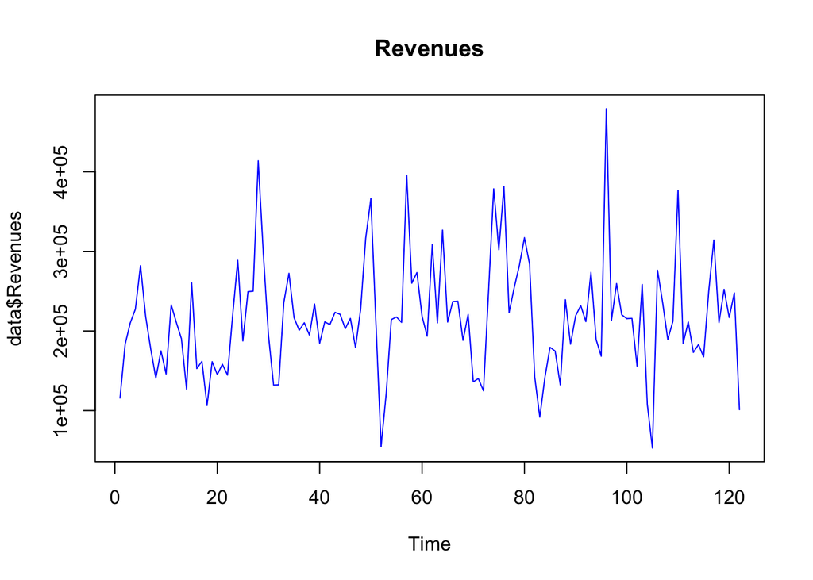

```r
ts.plot(data$Revenues, col="blue", main="Revenues")
```

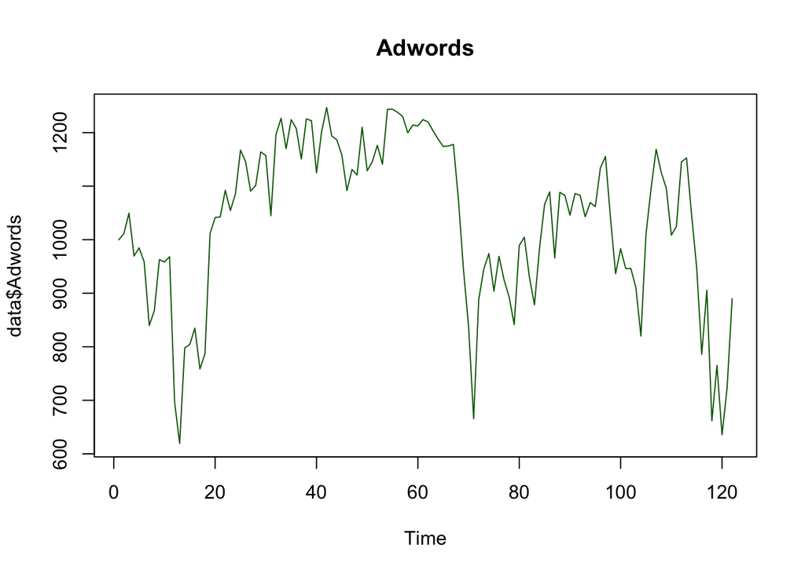

```r
ts.plot(data$Adwords, col="darkgreen", main="Adwords")
```

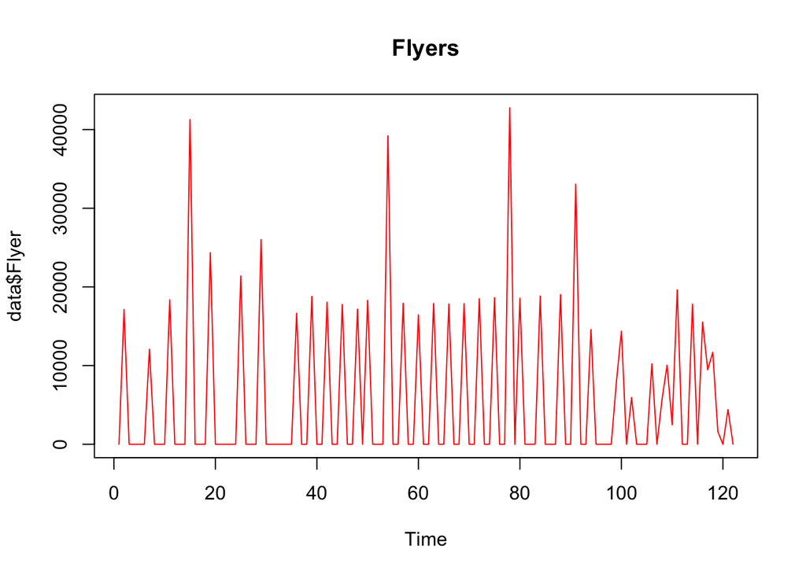

```r
ts.plot(data$Flyer, col="red", main="Flyers")
```

**Group Activity**: Looking at these plots, what do you observe? Do increases and decreases in sales coincide with adwords and flyers spending? Do you see any seasonality or trend patterns?

Given the available data, the key question is: are increases in adwords and flyer spending necessary to keep up the sales gains? As a marketing analyst, you would like to find an answer to this question by using an econometric approach.

## Analysis Steps:

- Perform unit root tests to check for non-stationary variables and take differences of the variables that are evolving.
- Estimate a vector autoregressive (VAR) model and interpret the coefficients.
- Estimate generalized impulse response functions (GIRFs) of sales to spending varialbes (i.e., Adwords and flyers).
- Evaluate the current and optimal budget allocation and make informed decisions regarding marketing resrouce allocation.

Now let’s start!

## Preparations for a VAR Model

First, given the large swings/turbulance of variables in the data, *taking log* can help to smooth out the series.

```r
data$LRevenue <- log(data$Revenues+1)
data$LAd <- log(data$Adwords+1)
data$LFlyer <- log(data$Flyer+1)
```

To determine if the series are evolving or stationary over time, we can plot ACF and(or) PACF for each variable to visualise first:

**ACF and PACF plots**

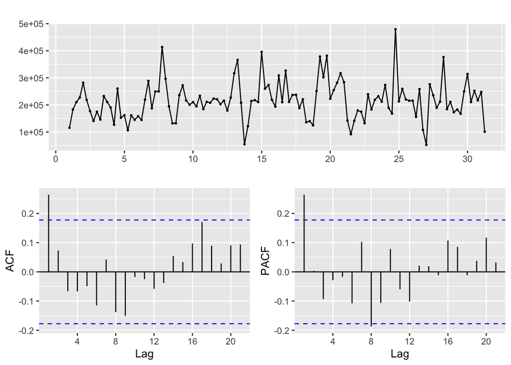

```r
Revenue <- ts(data$Revenues, frequency = 4, start = c(1, 1))

#test trend, there are multiple ways to plot
#plot.ts(Revenue)
#autoplot(Revenue)
ggtsdisplay(Revenue) #trend plot and ACF and PACF.
```

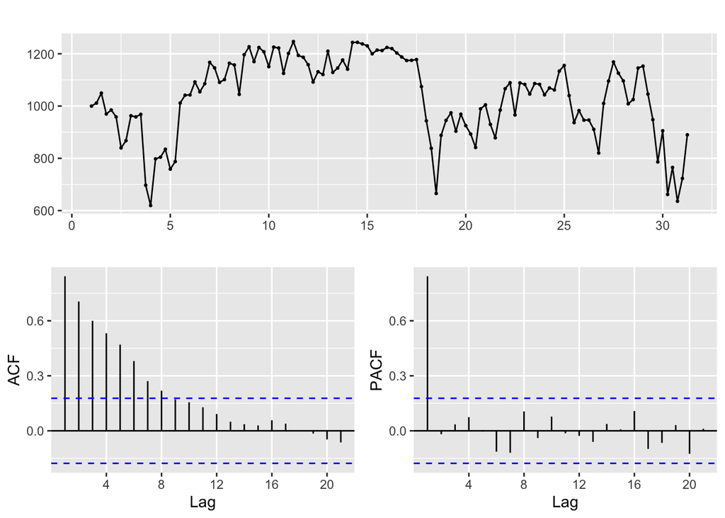

```r
ADV <- ts(data$Adwords, frequency = 4, start = c(1, 1))

#test trend, multiple ways to plot

ggtsdisplay(ADV)  #trend plot and ACF and PACF.
```

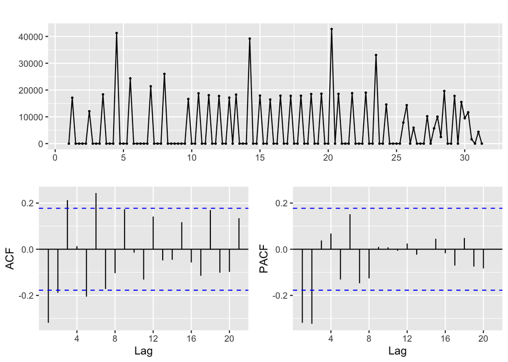

```r
FLYER <- ts(data$Flyer, frequency = 4, start = c(1, 1))

#test trend, multiple ways to plot
ggtsdisplay(FLYER) #trend plot and ACF and PACF.
```

**Unit Root Testing**

```r
LRev <- ts(data$LRevenue, frequency = 4, start = c(1, 1))
LAd <- ts(data$LAd, frequency = 4, start = c(1, 1))
LFLYER <- ts(data$LFlyer, frequency = 4, start = c(1, 1))


adf.test(LRev)
```

```
##
##  Augmented Dickey-Fuller Test
##
## data:  LRev
## Dickey-Fuller = -5.2428, Lag order = 4, p-value = 0.01
## alternative hypothesis: stationary
```

```r
adf.test(LAd)
```

```
##
##  Augmented Dickey-Fuller Test
##
## data:  LAd
## Dickey-Fuller = -2.0661, Lag order = 4, p-value = 0.5491
## alternative hypothesis: stationary
```

```r
adf.test(LFLYER)
```

```
##
##  Augmented Dickey-Fuller Test
##
## data:  LFLYER
## Dickey-Fuller = -6.5352, Lag order = 4, p-value = 0.01
## alternative hypothesis: stationary
```

Stationary tests have failed only for adwords spending (p-value>0.05)–there are serial correlation in the data. And that’s why before estimating the VAR model, based on unit root test results we need to take first difference for the evolving variable.

**Take first difference for non-stationary variables**

```r
#Take first difference of adwords spending series
DLAd <-diff(LAd, differences = 1)
```

Now we do the ADF test again to make sure that all variables are stationary :

```r
adf.test(LRev)
```

```
##
##  Augmented Dickey-Fuller Test
##
## data:  LRev
## Dickey-Fuller = -5.2428, Lag order = 4, p-value = 0.01
## alternative hypothesis: stationary
```

```r
adf.test(DLAd)
```

```
##
##  Augmented Dickey-Fuller Test
##
## data:  DLAd
## Dickey-Fuller = -5.0641, Lag order = 4, p-value = 0.01
## alternative hypothesis: stationary
```

```r
adf.test(LFLYER)
```

```
##
##  Augmented Dickey-Fuller Test
##
## data:  LFLYER
## Dickey-Fuller = -6.5352, Lag order = 4, p-value = 0.01
## alternative hypothesis: stationary
```

Stationary tests suggest that now the three variables (with adwords spending first-differenced) are all stationary.

## Construct a VAR model

First we need to build a dataset for VAR model.

```r
data.ts.d1 <- window(cbind(LRev, DLAd, LFLYER), start = c(1, 2))
data_for_var <- gen_var(data.ts.d1, p = 1, deterministic = "const")
y <- data_for_var$Y[, 1:120]
x <- data_for_var$Z[, 1:120]
```

**Bayesian estimator**

The following code is a Gibbs sampler for a simple VAR model with non-informative priors.

```r
# Reset random number generator for reproducibility
set.seed(1234567)

iter <- 10000 # Number of iterations of the Gibbs sampler
burnin <- 5000 # Number of burn-in draws
store <- iter - burnin

t <- ncol(y) # Number of observations
k <- nrow(y) # Number of endogenous variables
m <- k * nrow(x) # Number of estimated coefficients

# Set (uninformative) priors
a_mu_prior <- matrix(0, m) # Vector of prior parameter means
a_v_i_prior <- diag(0, m) # Inverse of the prior covariance matrix

u_sigma_df_prior <- 0 # Prior degrees of freedom
u_sigma_scale_prior <- diag(0, k) # Prior covariance matrix
u_sigma_df_post <- t + u_sigma_df_prior # Posterior degrees of freedom

# Initial values
u_sigma_i <- diag(.00001, k)
u_sigma <- solve(u_sigma_i)

# Data containers for posterior draws
draws_a <- matrix(NA, m, store)
draws_sigma <- matrix(NA, k^2, store)



# Start Gibbs sampler
for (draw in 1:iter) {
  # Draw conditional mean parameters
  a <- post_normal(y, x, u_sigma_i, a_mu_prior, a_v_i_prior)

  # Draw variance-covariance matrix
  u <- y - matrix(a, k) %*% x # Obtain residuals
  u_sigma_scale_post <- solve(u_sigma_scale_prior + tcrossprod(u))
  u_sigma_i <- matrix(rWishart(1, u_sigma_df_post, u_sigma_scale_post)[,, 1], k)
  u_sigma <- solve(u_sigma_i) # Invert Sigma_i to obtain Sigma

  # Store draws
  if (draw > burnin) {
    draws_a[, draw - burnin] <- a
    draws_sigma[, draw - burnin] <- u_sigma
  }
}
```

**Results**

After the Gibbs sampler has finished, point estimates can be obtained as the mean of the posterior draws:

```r
A <- rowMeans(draws_a) # Obtain means for every row
A <- matrix(A, k) # Transform mean vector into a matrix
A <- round(A, 3) # Round values
dimnames(A) <- list(dimnames(y)[[1]], dimnames(x)[[1]]) # Rename matrix dimensions


Sigma <- rowMeans(draws_sigma) # Obtain means for every row
Sigma <- matrix(Sigma, k) # Transform mean vector into a matrix
Sigma <- round(Sigma * 10^4, 2) # Round values
dimnames(Sigma) <- list(dimnames(y)[[1]], dimnames(y)[[1]]) # Rename matrix dimensions



A #Print results of BVAR
```

```
##        LRev.1 DLAd.1 LFLYER.1 const
## LRev    0.311  0.404    0.003 8.414
## DLAd   -0.063 -0.147    0.000 0.765
## LFLYER  0.330 -4.399   -0.274 0.045
```

**Question**:From your output, identify the carryover, direct, feedback and cross effects. What is your interpretation? Besides, revenues could be impacted by its own past values, hence being endogenous. How do you check for causality in this case? Discuss with your classmates.

Having estimated the VAR and discuss the relationships between sales, adwords spending, and flyer spending, now we are able to explore:

- Short vs long-term effects of Adwords and Flyer spending
- Optimal allocation between Adwords and Flyer spending

To do these, we need GIRF analysis

**GIRF Analysis**  
The bvar function can be used to collect relevant output of the Gibbs sampler into a standardised object, which can be used by further functions such as predict to obtain forecasts or irf for impulse respons analysis.

```r
bvar_est <- bvar(y = y, x = x, A = draws_a[1:9,],
                 C = draws_a[10:12, ], Sigma = draws_sigma)
```

Now we obtain the GIRF coefficients and plots for Adwords spending and flyer spending, respectively.

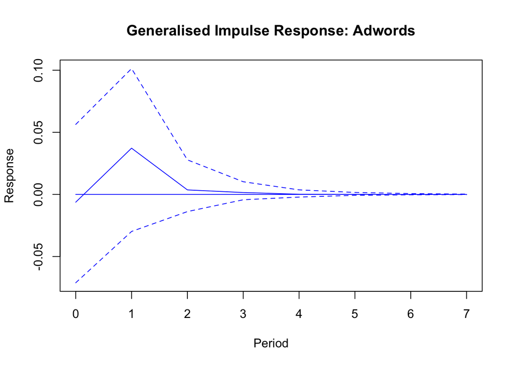

```r
#Adwords
GIR_Ad <- irf(bvar_est, impulse ="DLAd" , response = "LRev", n.ahead = 7, type = "gir")
plot(GIR_Ad, main = "Generalised Impulse Response: Adwords", xlab = "Period", ylab = "Response", col="blue")
```

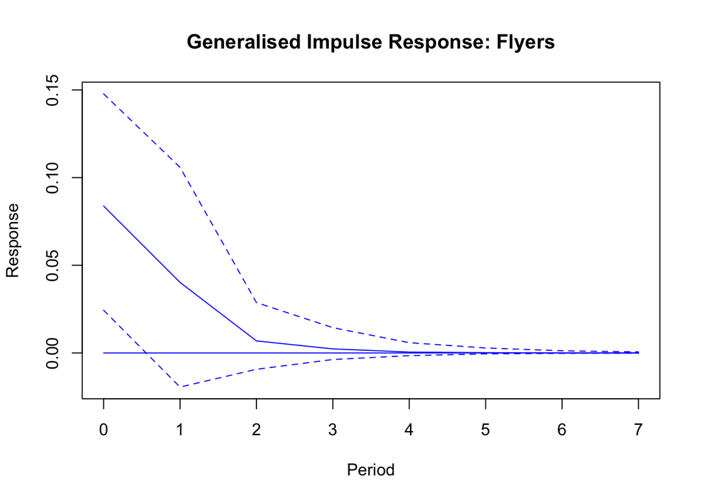

```r
#Flyer
GIR_FLYER <- irf(bvar_est, impulse ="LFLYER" , response = "LRev", n.ahead = 7, type = "gir")
plot(GIR_FLYER, main = "Generalised Impulse Response: Flyers", xlab = "Period", ylab = "Response", col="blue")
```

Now let’s evaluate GIRF coefficients in detail to calculate the long-run elasticities of adwords and flyer spending.

**Immediate and Long-Term Effects**  
In order to compute the immediate and long-term effects, the following steps should be taken.

- Evaluate the significance of each GIRF coefficient. If the t-statistics of the GIRF coefficient is greater than 1 (t-stat>1), then we treat it as signficant and keep the value of that coefficient; otherwise, we treat the coefficient as zero.
- Since the given shock is a standard deviation shock, it is advised to divide the GIRF coefficient by the standard deviation of the variable.
- Finally, based on the above computations, the first period impact is called the immediate effect while the cumulative effect over 8 periods is called the long-run effect.

To calculate the t-statistics, we need to

- Derive the standard error $(se)$ of each coefficient from its confidence interval, since $Lowerbound_{ci}= \beta - t*se$ $Upperbound_{ci}= \beta + t*se$ (Note that here the $t$ value is obtained from t-distribution for a given degree of freedom and significance level)
- Calculat the t-statistics using $t_{stat} = \beta / se$.

```r
#Adwords spending
round(GIR_Ad,3) # Frist take a look at the GIRF coefficients (lower bound of confidence interval, estimated coefficient, upper bound of confidence interval)
```

```
## Time Series:
## Start = 0
## End = 7
## Frequency = 1
##     2.5%    50% 97.5%
## 0 -0.071 -0.006 0.056
## 1 -0.030  0.037 0.101
## 2 -0.014  0.004 0.028
## 3 -0.004  0.002 0.010
## 4 -0.002  0.000 0.004
## 5 -0.001  0.000 0.002
## 6  0.000  0.000 0.001
## 7  0.000  0.000 0.000
```

```r
t_stat<-1.9823

se_GIR_Ad <- matrix(ncol = 1, nrow = 8) #set up a matrix to save standard error for each coefficient
t_GIR_Ad <- matrix(ncol=1, nrow=8) #set up a matrix to store t stat for each coefficient
result_GIR_Ad <- matrix(ncol=1, nrow=8) #set up a matrix to store significant coefficient and others as zeros

for (i in 1:8) {
  se <- (GIR_Ad[i,3]-GIR_Ad[i,1])/(2*t_stat)
  se_GIR_Ad[i,1]<- se
   t_GIR_Ad[i,1]<- GIR_Ad[i,2]/se

   if (t_GIR_Ad[i,1]>1) {
    result_GIR_Ad[i,1] <-GIR_Ad[i,2]
   } else {
      result_GIR_Ad[i,1] <-0
      } #if the t-statistics is larger than 1, then we keep the coefficient, otherwise we treat it as zero
}

result_GIR_Ad #print the GIRF coefficients used for evaluating long-run elasticities
```

```
##            [,1]
## [1,] 0.00000000
## [2,] 0.03725434
## [3,] 0.00000000
## [4,] 0.00000000
## [5,] 0.00000000
## [6,] 0.00000000
## [7,] 0.00000000
## [8,] 0.00000000
```

```r
lr_GIR_Ad <- round(sum(result_GIR_Ad/sd(DLAd)),4) #long-run elasticities
lr_GIR_Ad
```

```
## [1] 0.3912
```

```r
#Flyer spending
round(GIR_FLYER,3)
```

```
## Time Series:
## Start = 0
## End = 7
## Frequency = 1
##     2.5%   50% 97.5%
## 0  0.024 0.084 0.148
## 1 -0.019 0.040 0.106
## 2 -0.009 0.007 0.029
## 3 -0.004 0.002 0.014
## 4 -0.002 0.001 0.006
## 5 -0.001 0.000 0.003
## 6  0.000 0.000 0.001
## 7  0.000 0.000 0.001
```

```r
se_GIR_FLYER <- matrix(ncol = 1, nrow = 8)
t_GIR_FLYER <- matrix(ncol=1, nrow=8)
result_GIR_FLYER <- matrix(ncol=1, nrow=8)

for (i in 1:8) {
  se <- (GIR_FLYER[i,3]-GIR_FLYER[i,1])/(2*t_stat)
  se_GIR_FLYER[i,1]<- se
   t_GIR_FLYER[i,1]<- GIR_FLYER[i,2]/se

   if (t_GIR_FLYER[i,1]>1) {
    result_GIR_FLYER[i,1] <-GIR_FLYER[i,2]
   } else {
      result_GIR_FLYER[i,1] <-0
      }
}

result_GIR_FLYER
```

```
##            [,1]
## [1,] 0.08377371
## [2,] 0.04025419
## [3,] 0.00000000
## [4,] 0.00000000
## [5,] 0.00000000
## [6,] 0.00000000
## [7,] 0.00000000
## [8,] 0.00000000
```

```r
lr_GIR_FLYER <- round(sum(result_GIR_FLYER/sd(LFLYER)),4)
lr_GIR_FLYER #long-run elasticities
```

```
## [1] 0.0271
```

## Optimal Allocation between Adwords and Flyer Spending

Before we figure out the optimal budget allocation between adwords and flyer spending, we can first take a look at what the current budget allocation of the firm looks like. We just need to review the dataset we have and visualize the proportion that the firm is spending on adwords and flyers, respectively.

```r
#Current budget allocation

cost_adwords<-sum(data$Adwords)
cost_flyer<-sum(data$Flyer)
cost_total <- cost_adwords + cost_flyer

costshare_adwords<-cost_adwords/cost_total
costshare_flyer<-cost_flyer/cost_total
```

Now we can create a pie chart to visualize the current budget allocation of the firm.

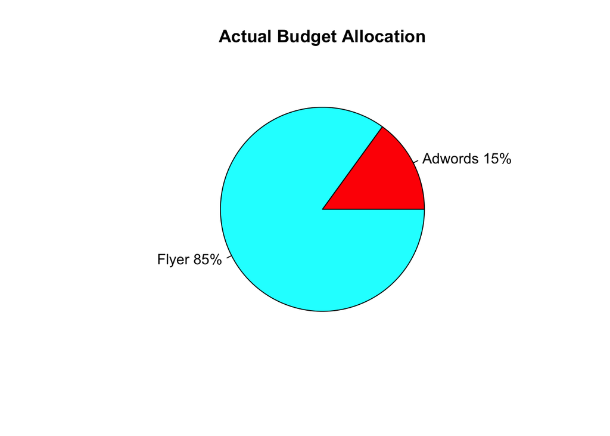

```r
# Ingredients for the pie-chart
slices_actual<-c(costshare_adwords, costshare_flyer )
lbls_actual<-c("Adwords", "Flyer")
pct_actual<-round(slices_actual*100)
lbls_actual<-paste(lbls_actual, pct_actual)          # add data to labels
lbls_actual<-paste(lbls_actual, "%", sep="")  # add % sign to labels

# Get the pie-chart
pie(slices_actual, labels=lbls_actual, col=rainbow(length(lbls_actual)), main="Actual Budget Allocation" )
```

We can see that the firm is currently putting a major proportion of 85% of its budget on flyer advertising and only 15% on Google adwords advertising.

**Question** Given what we have obtained from the VAR model, do you think the current budget allocation strategy of the firm is good/close to optimum?

For the optimal allocation, we need to retrieve the impact of adwords and flyer spending from IRF analysis. More specifically, we will calculate the optimal allocation for each media using the following formula:

$$OptimalAllocation_i= \frac{\eta_i} {\sum_{i=1}^{I}{\eta_i}}$$

where $\eta_i$ is the sales elasticity of marketing tool $i$. As an example, for Adwords spending, we will calculate it as follows:

$$OptimalAllocation_{Adwords}= \frac{\eta_{Adwords}} {\eta_{Adwords} + \eta_{Flyer}}$$

Let’s do this in R now:

```r
#Get the coefficients from GIRF results
beta_adwords<-lr_GIR_Ad
beta_flyer<-lr_GIR_FLYER

#The sum of all elasticities
beta_all<-beta_adwords+beta_flyer

#Optimal resource allocation
optim_adwords<-beta_adwords/beta_all
optim_flyer<-beta_flyer/beta_all
```

Having figured out the optimal budget allocation between adwords and flyer, we can now create another pie chart so that we can compare:

```r
## Pie-chart ingredients
optimal_spend<-c(optim_adwords,optim_flyer)
optimal_spend=round(optimal_spend, digits=5)
optimal_spend
```

```
## [1] 0.93521 0.06479
```

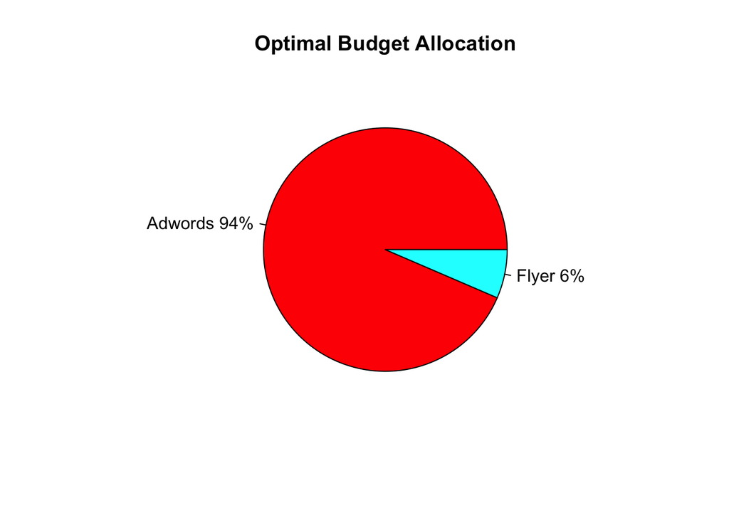

```r
slices_optim<-c(optim_adwords, optim_flyer)
lbls_optim<-c("Adwords", "Flyer")
pct_optim<-round(slices_optim*100)
lbls_optim<-paste(lbls_optim, pct_optim)   # paste variable names to data labels
lbls_optim<-paste(lbls_optim, "%", sep="") # add % sign to labels

# Get the pie-chart
pie(slices_optim, labels=lbls_optim, col=rainbow(length(lbls_optim)), main="Optimal Budget Allocation" )
```

The optimal budget allocation is rather surprising–the firm should actually spend almost all of its marketing budget on Adwords advertising (94%) and should put marginal effort (6%) on offline flyers, given its very low effectiveness (i.e., long-term elasticities) compared with taht of Adwords.

Contrasting the optimal and actual budget allocation of the firm, it is quite obvious that currently the firm is wastng too much of its financial resource on flyers, which contribute very little to its revenues.

We can see that without analyzing resoruce allocation, a firm can be quite far away from what it “should” do. Taking a look at the optimal budget allocation is quite critical in managers’ decision making, since utilizing the constrainted resource more wisely can potentially make a big difference to firm performance (e.g., revenues).

This session talks about the allocation when the sales performance is taken into consideration. Brand managers may pursue different KPIs as well, such as market share, profits, and brand liking. With different KPIs pursued by the brand manager, allocation would be different. Moreover, instead of keeping the budget the same and reallocating it, the brand manager may want to increase the budget. In such a case, the dynamics between marketing input and financial performance would be altered, leading to different optimal allocation

## Application Exercise

In this session we evaluated the resource allocation between advertising effort in adwords and flyers spending. Now it is your time to apply what you’ve learned in another real world data!

In the file *resource_allocation_application.xlsx*, you are given 70 weeks’ sales information (*Revenue* in the dataset) of another kithen appliance brand. More importantly, you are also given the online advertising spending (*Online* in the dataset) and spending on offline channel (*Offline* in the dataset).

Can you help the firm evaluate the short-term and long-term impact of online and offline spending, and determine the optimal budget allocation between them?